# 招聘信息可视化

```python
import pandas as pd
job=pd.read_csv('./boss岗位.csv')
job.head()
```

|  | 标题 | 地区 | 公司名 | 公司领域 | 薪资 | 经验 | 规模 | 福利 | 详情页 |
| --- | --- | --- | --- | --- | --- | --- | --- | --- | --- |
| 0 | 数据分析师 | 北京·海淀区·公主坟 | 锐捷网络 | 通信/网络设备 | 20-30K·13薪 | 3-5年本科 | 1000-9999人 | 通讯补贴，节日福利，五险一金，定期体检，带薪年假，餐补，包吃，加班补助，员工旅游，零食下午茶... | https://www.zhipin.com/job_detail/42975c4fd5ea... |
| 1 | 数据分析师 | 上海·浦东新区·张江 | 中电金信 | 计算机软件 | 15-25K | 经验不限本科 | 10000人以上 | 定期体检，节日福利，五险一金，补充医疗保险，带薪年假，零食下午茶 | https://www.zhipin.com/job_detail/3f9754994eb4... |
| 2 | 数据分析师 | 北京·大兴区·亦庄 | 沃东天骏信息技术 | 电子商务 | 30-60K·14薪 | 5-10年本科 | 10000人以上 | 加班补助，免费班车，带薪年假，定期体检，补充医疗保险，全勤奖，餐补，年终奖，股票期权，节日福... | https://www.zhipin.com/job_detail/fc118cb2b449... |
| 3 | 数据分析师 | 北京·海淀区·马连洼 | 滴滴 | 移动互联网 | 15-30K·15薪 | 3-5年本科 | 1000-9999人 | 定期体检，补充医疗保险，五险一金 | https://www.zhipin.com/job_detail/805d4a645e38... |
| 4 | 数据分析师 | 北京·海淀区·清河 | 小米 | 互联网 | 15-30K·14薪 | 3-5年本科 | 10000人以上 | 餐补，补充医疗保险，股票期权，年终奖，五险一金，定期体检，节日福利，12%公积金，带薪年假 | https://www.zhipin.com/job_detail/6fd7b042d6f7... |

```python
job1= job.copy() # 复制数据，不在元数据上改动
```

### 岗位分析

```python
job1=pd.DataFrame(job1)
job1.head(1)
```

|  | 标题 | 地区 | 公司名 | 公司领域 | 薪资 | 经验 | 规模 | 福利 | 详情页 |
| --- | --- | --- | --- | --- | --- | --- | --- | --- | --- |
| 0 | 数据分析师 | 北京·海淀区·公主坟 | 锐捷网络 | 通信/网络设备 | 20-30K·13薪 | 3-5年本科 | 1000-9999人 | 通讯补贴，节日福利，五险一金，定期体检，带薪年假，餐补，包吃，加班补助，员工旅游，零食下午茶... | https://www.zhipin.com/job_detail/42975c4fd5ea... |

```python
job1.shape
```

```
(2913, 9)
```

```python
import matplotlib.pyplot as plt
import seaborn as sns
plt.rcParams['font.sans-serif'] = 'SimHei' ## 设置中文显示
import warnings
warnings.filterwarnings('ignore')

x = job1['标题'].value_counts()
#x = x.sort_values(ascending=False)
x=x.sort_values(ascending=False)[0:30]
x
```

```
数据分析师         162
大数据开发         156
大数据开发工程师      118
Python        117
爬虫工程师         106
运维工程师          98
测试工程师          96
大数据工程师         64
后端开发工程师        55
web前端          48
前端开发           44
web前端开发工程师     41
人工智能训练师        36
大数据            34
运维             29
数据挖掘工程师        29
前端开发工程师        28
web前端开发        27
学习管理师          27
后端开发           26
人工智能           25
数据分析           24
数据挖掘           22
学习规划师          19
爬虫实习生          19
人工智能工程师        18
python         18
机器学习           17
机器学习算法工程师      15
大数据开发实习生       14
Name: 标题, dtype: int64
```

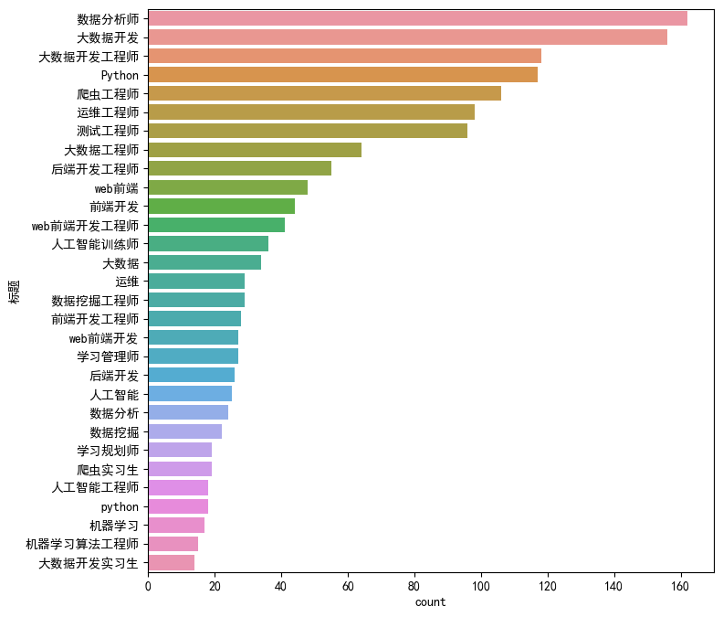

```python
#前30种工作岗位招聘
plt.figure(figsize=(8,8))
sns.countplot(data=job1, y='标题',orient='v',order=x.index)
plt.show()
```

- 关于招聘岗位的分析: 岗位总量为2913，招聘的岗位主要为数据分析师、大数据开发等数据挖掘与分析工作

### 地区分析（尝试使用pyecharts绘制地图）

```python
job1['地区'].unique()
```

```
array(['北京·海淀区·公主坟', '上海·浦东新区·张江', '北京·大兴区·亦庄', ..., '东莞·长安镇·长安新区',
       '东莞·寮步镇·凫山', '海口·美兰区·明珠广场'], dtype=object)
```

```python
job1['地区']=job1['地区'].str[:2]
x1= job1['地区'].value_counts()
#x1 = x.sort_values(ascending=False)
x1=pd.DataFrame(x1)
x1=x1.reset_index()#将行名转变为列
x1.columns=['地区','岗位数量']
x1['地区']=x1['地区']+'市'
x1
```

|  | 地区 | 岗位数量 |
| --- | --- | --- |
| 0 | 北京市 | 445 |
| 1 | 上海市 | 290 |
| 2 | 深圳市 | 222 |
| 3 | 杭州市 | 191 |
| 4 | 南京市 | 145 |
| ... | ... | ... |
| 172 | 聊城市 | 1 |
| 173 | 宿迁市 | 1 |
| 174 | 江门市 | 1 |
| 175 | 鹤壁市 | 1 |
| 176 | 克孜市 | 1 |

177 rows × 2 columns

```python
#!pip install pyecharts
from pyecharts import options as opts
from pyecharts.charts import Map
from pyecharts.faker import Faker

d = (
    Map()
    .add('地区就业机会密度地图',[list(z) for z in zip(x1['地区'],x1['岗位数量'])], "china-cities",label_opts=opts.LabelOpts(is_show=False))
    .set_global_opts(title_opts=opts.TitleOpts(title="工作岗位地区示例"),visualmap_opts=opts.VisualMapOpts())

   # .render("map_base.html")
)
d.render_notebook()
```

- 根据工作岗位的地区分布可知：工作工位集中分布在北京市、上海市、深圳市、杭州市、南京市等信息技术发达的城市

### 公司薪资分析（把薪资拆成底薪和顶薪作核密度曲线，十x薪作个柱形图）

```python
job1['公司名'].unique().shape
```

```
(1936,)
```

```python
job1.head(1)
```

|  | 标题 | 地区 | 公司名 | 公司领域 | 薪资 | 经验 | 规模 | 福利 | 详情页 |
| --- | --- | --- | --- | --- | --- | --- | --- | --- | --- |
| 0 | 数据分析师 | 北京 | 锐捷网络 | 通信/网络设备 | 20-30K·13薪 | 3-5年本科 | 1000-9999人 | 通讯补贴，节日福利，五险一金，定期体检，带薪年假，餐补，包吃，加班补助，员工旅游，零食下午茶... | https://www.zhipin.com/job_detail/42975c4fd5ea... |

```python
type(job1['薪资'])
```

```
pandas.core.series.Series
```

```python
job2= job1.copy()
```

```python
job2['薪资标签']=job2['薪资'].str[-1]
job2.head(2)
```

|  | 标题 | 地区 | 公司名 | 公司领域 | 薪资 | 经验 | 规模 | 福利 | 详情页 | 薪资标签 |
| --- | --- | --- | --- | --- | --- | --- | --- | --- | --- | --- |
| 0 | 数据分析师 | 北京 | 锐捷网络 | 通信/网络设备 | 20-30K·13薪 | 3-5年本科 | 1000-9999人 | 通讯补贴，节日福利，五险一金，定期体检，带薪年假，餐补，包吃，加班补助，员工旅游，零食下午茶... | https://www.zhipin.com/job_detail/42975c4fd5ea... | 薪 |
| 1 | 数据分析师 | 上海 | 中电金信 | 计算机软件 | 15-25K | 经验不限本科 | 10000人以上 | 定期体检，节日福利，五险一金，补充医疗保险，带薪年假，零食下午茶 | https://www.zhipin.com/job_detail/3f9754994eb4... | K |

```python
job2['底薪']=job2['薪资'].str.extract(r'(\d+)-').astype(float)#使用正则表达式模式来提取数值部分
job2['顶薪']=job2['薪资'].str.extract(r'-(\d+)').astype(float)
job2.head()
```

|  | 标题 | 地区 | 公司名 | 公司领域 | 薪资 | 经验 | 规模 | 福利 | 详情页 | 薪资标签 | 底薪 | 顶薪 |
| --- | --- | --- | --- | --- | --- | --- | --- | --- | --- | --- | --- | --- |
| 0 | 数据分析师 | 北京 | 锐捷网络 | 通信/网络设备 | 20-30K·13薪 | 3-5年本科 | 1000-9999人 | 通讯补贴，节日福利，五险一金，定期体检，带薪年假，餐补，包吃，加班补助，员工旅游，零食下午茶... | https://www.zhipin.com/job_detail/42975c4fd5ea... | 薪 | 20.0 | 30.0 |
| 1 | 数据分析师 | 上海 | 中电金信 | 计算机软件 | 15-25K | 经验不限本科 | 10000人以上 | 定期体检，节日福利，五险一金，补充医疗保险，带薪年假，零食下午茶 | https://www.zhipin.com/job_detail/3f9754994eb4... | K | 15.0 | 25.0 |
| 2 | 数据分析师 | 北京 | 沃东天骏信息技术 | 电子商务 | 30-60K·14薪 | 5-10年本科 | 10000人以上 | 加班补助，免费班车，带薪年假，定期体检，补充医疗保险，全勤奖，餐补，年终奖，股票期权，节日福... | https://www.zhipin.com/job_detail/fc118cb2b449... | 薪 | 30.0 | 60.0 |
| 3 | 数据分析师 | 北京 | 滴滴 | 移动互联网 | 15-30K·15薪 | 3-5年本科 | 1000-9999人 | 定期体检，补充医疗保险，五险一金 | https://www.zhipin.com/job_detail/805d4a645e38... | 薪 | 15.0 | 30.0 |
| 4 | 数据分析师 | 北京 | 小米 | 互联网 | 15-30K·14薪 | 3-5年本科 | 10000人以上 | 餐补，补充医疗保险，股票期权，年终奖，五险一金，定期体检，节日福利，12%公积金，带薪年假 | https://www.zhipin.com/job_detail/6fd7b042d6f7... | 薪 | 15.0 | 30.0 |

```python
#将不同的底薪和顶薪换算为月工资，假设一个月为30天，一天工作8小时，将薪酬换算为日薪
ind = (job2['薪资标签']=='薪')
ind1 = (job2['薪资标签']=='K')
ind2 = (job2['薪资标签']=='月')
ind3 = (job2['薪资标签']=='时')
job2.loc[ind,['底薪','顶薪']]= job2.loc[ind,['底薪','顶薪']]*1000/30
job2.loc[ind1,['底薪','顶薪']]= job2.loc[ind1,['底薪','顶薪']]*1000/30
job2.loc[ind2,['底薪','顶薪']]= job2.loc[ind2,['底薪','顶薪']]/30
job2.loc[ind3,['底薪','顶薪']]= job2.loc[ind3,['底薪','顶薪']]*8
#[ind][['列']]先索引行再索引列不能赋值，行和列要一起赋值
```

```python
job2.loc[ind,['薪资标签']]='双薪日工资'
job2.loc[ind1,['薪资标签']]='月薪日工资'
job2.loc[ind2,['薪资标签']]='月薪日工资'
job2.loc[ind3,['薪资标签']]='时薪日工资'
job2.loc[job2['薪资标签']=='天',['薪资标签']]='日工资'
```

```python
job2[ind2]
```

|  | 标题 | 地区 | 公司名 | 公司领域 | 薪资 | 经验 | 规模 | 福利 | 详情页 | 薪资标签 | 底薪 | 顶薪 |
| --- | --- | --- | --- | --- | --- | --- | --- | --- | --- | --- | --- | --- |
| 1164 | 桓台县+兼职+门店数据统计人员 | 淄博 | 蓝月亮 | 生活服务 | 500-1000元/月 | 经验不限学历不限 | 10000人以上 | 节日福利，五险一金，带薪年假，免费班车，加班补助，免费住宿，零食下午茶，定期体检，餐补 | https://www.zhipin.com/job_detail/9029e89c04fc... | 月薪日工资 | 16.666667 | 33.333333 |

```python
job2[ind3]
```

|  | 标题 | 地区 | 公司名 | 公司领域 | 薪资 | 经验 | 规模 | 福利 | 详情页 | 薪资标签 | 底薪 | 顶薪 |
| --- | --- | --- | --- | --- | --- | --- | --- | --- | --- | --- | --- | --- |
| 1103 | 数据标注 | 太原 | 山西梓柒科技有限公司 | 互联网 | 10-20元/时 | 经验不限大专 | 0-20人 | 五险一金，包住 | https://www.zhipin.com/job_detail/926b626decad... | 时薪日工资 | 80.0 | 160.0 |
| 1243 | 人工智能 | 宝鸡 | 宝鸡高新区生产力... | 企业服务 | 5-50元/时 | 经验不限大专 | 0-20人 | NaN | https://www.zhipin.com/job_detail/3c2d85d7c164... | 时薪日工资 | 40.0 | 400.0 |

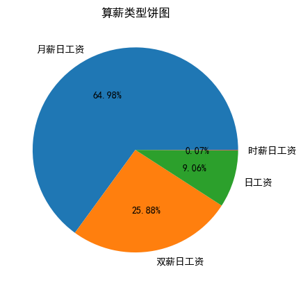

```python
#标签薪表示该薪酬的算薪月份一年大于等于12个月
#k和月标签表示该薪酬的算薪月份一年为12月
#天表示该薪酬按月计算
#时，表示薪酬按小时计算
#下图的薪酬换算为日薪比较
x = job2["薪资标签"].value_counts()
plt.pie(x=x, labels=x.index, autopct='%.2f%%')
plt.title('算薪类型饼图')
plt.show()
```

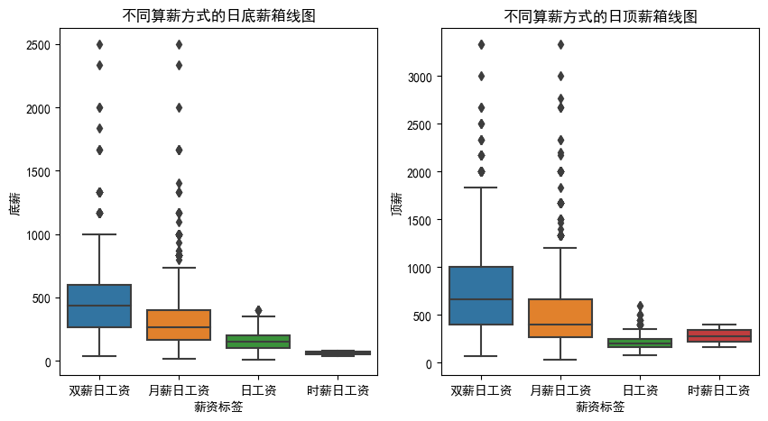

```python
plt.figure(figsize=(10,5))
plt.subplot(1,2,1)
sns.boxplot(data=job2,
    x="薪资标签",y="底薪")
plt.title('不同算薪方式的日底薪箱线图')


plt.subplot(1,2,2)
sns.boxplot(data=job2,
    x="薪资标签",y="顶薪")
plt.title('不同算薪方式的日顶薪箱线图')
plt.show()
```

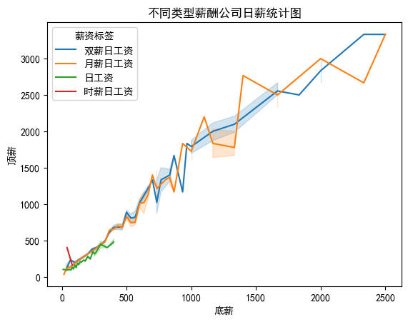

```python
import seaborn as sns
import matplotlib.pyplot as plt

sns.lineplot(data=job2,
    x="底薪",y="顶薪",hue="薪资标签")#在数据区间（最大最小值里面）里面，折线为均值线
plt.title('不同类型薪酬公司日薪统计图')
plt.show()
```

- 双薪计算公司在日底薪为700-900，1000-1750区间，顶薪的浮动较大
- 月薪计算公司在日底薪为1200-1500区间，顶薪的浮动较大

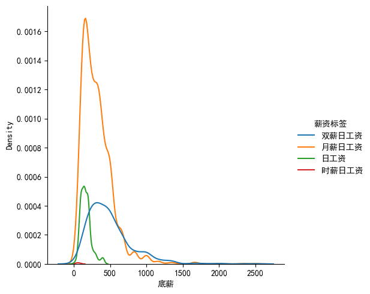

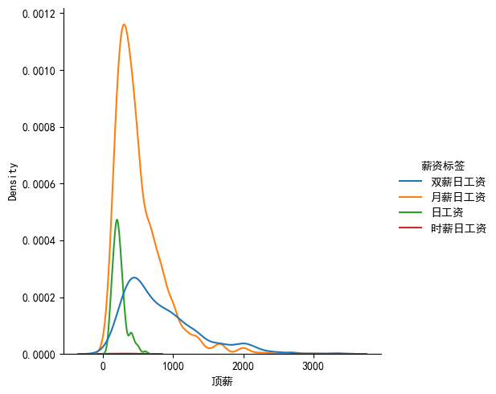

```python
plt.figure(figsize=(8,15))
sns.displot(data=job2,
    x="底薪", hue='薪资标签', kind='kde')
sns.displot(data=job2,
    x="顶薪", hue='薪资标签', kind='kde')

plt.show()
```

- 双薪计算公司的日底薪主要集中在100-700，顶薪集中在200-1200
- 月薪计算公司的日底薪主要集中在0-550，顶薪集中在50-1000
- 日薪计算公司的日底薪主要集中在0-300，顶薪集中在50-400
- 时薪计算公司为极少数

### 规模分析

```python
job3=job2.copy()
```

```python
job3.head(2)
```

|  | 标题 | 地区 | 公司名 | 公司领域 | 薪资 | 经验 | 规模 | 福利 | 详情页 | 薪资标签 | 底薪 | 顶薪 |
| --- | --- | --- | --- | --- | --- | --- | --- | --- | --- | --- | --- | --- |
| 0 | 数据分析师 | 北京 | 锐捷网络 | 通信/网络设备 | 20-30K·13薪 | 3-5年本科 | 1000-9999人 | 通讯补贴，节日福利，五险一金，定期体检，带薪年假，餐补，包吃，加班补助，员工旅游，零食下午茶... | https://www.zhipin.com/job_detail/42975c4fd5ea... | 双薪日工资 | 666.666667 | 1000.000000 |
| 1 | 数据分析师 | 上海 | 中电金信 | 计算机软件 | 15-25K | 经验不限本科 | 10000人以上 | 定期体检，节日福利，五险一金，补充医疗保险，带薪年假，零食下午茶 | https://www.zhipin.com/job_detail/3f9754994eb4... | 月薪日工资 | 500.000000 | 833.333333 |

```python
#df=pd.DataFrame({'规模':['1000-9999人','10000人以上','500-999人','20-99人','0-20人','10000人以上']})
```

```python
import pandas as pd
import re
def extract_value(text):#定义函数
    pattern=r'(\d+)-(\d+)|(\d+)人以上'#正则表达式
    match=re.search(pattern,text)#
    if match:
        if match.group(1) and match.group(2):
            lower=int(match.group(1))
            upper=int(match.group(2))
            return (lower+upper)/2
        elif match.group(3):
            return int(match.group(3))
    return None
job3['公司的估计规模']=job3['规模'].apply(extract_value)
#re.search() 是 Python 中 re 模块提供的一个函数，用于在字符串中搜索匹配正则表达式的内容。它返回一个 Match 对象，表示找到的第一个匹配项，如果没有找到匹配项，则返回 None。
#参数说明：
#pattern：要匹配的正则表达式模式。
#string：要搜索的字符串。
#flags：可选参数，用于控制正则表达式的匹配方式。常用的标志包括 re.I（忽略大小写）、re.M（多行模式）、re.S（使 . 匹配换行符）、re.X（允许注释和空格）等。
#返回值：

#如果找到匹配项，则返回一个 Match 对象，可以通过该对象的方法和属性获取匹配结果。
#如果没有找到匹配项，则返回 None。
#re.search() 只返回第一个匹配项。如果要搜索所有匹配项，可以使用 re.findall() 函数。另外，还可以使用 re.match() 函数从字符串的开头开始匹配，而不是在整个字符串中搜索。
```

```python
job3['公司的估计规模']=job3['公司的估计规模'].astype(int)#化为整数
```

```python
#按照底薪分为5个标签
def label_value(value):
    if value<100:
        return "日底薪在200以下"
    elif value<300:
        return "日底薪在200-300"
    elif value<400:
        return "日底薪在300-400"
    elif value<500:
         return "日底薪在400-500"
    elif value<600:
        return "日底薪在500-600"
    else:
        return "日底薪在600以上"

job3['底薪标签']=[label_value(value) for value in job3["底薪"]]
```

```python
job3.head(2)
```

|  | 标题 | 地区 | 公司名 | 公司领域 | 薪资 | 经验 | 规模 | 福利 | 详情页 | 薪资标签 | 底薪 | 顶薪 | 公司的估计规模 | 底薪标签 |
| --- | --- | --- | --- | --- | --- | --- | --- | --- | --- | --- | --- | --- | --- | --- |
| 0 | 数据分析师 | 北京 | 锐捷网络 | 通信/网络设备 | 20-30K·13薪 | 3-5年本科 | 1000-9999人 | 通讯补贴，节日福利，五险一金，定期体检，带薪年假，餐补，包吃，加班补助，员工旅游，零食下午茶... | https://www.zhipin.com/job_detail/42975c4fd5ea... | 双薪日工资 | 666.666667 | 1000.000000 | 5499.5 | 日底薪在600以上 |
| 1 | 数据分析师 | 上海 | 中电金信 | 计算机软件 | 15-25K | 经验不限本科 | 10000人以上 | 定期体检，节日福利，五险一金，补充医疗保险，带薪年假，零食下午茶 | https://www.zhipin.com/job_detail/3f9754994eb4... | 月薪日工资 | 500.000000 | 833.333333 | 10000.0 | 日底薪在500-600 |

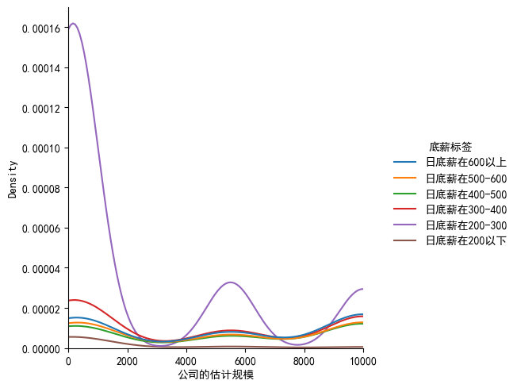

```python
sns.displot(data=job3,
    x="公司的估计规模", hue='底薪标签', kind='kde')
plt.xlim(0,max(job3['公司的估计规模']))
plt.show()
```

```python
#求各个市的公司的平均估计规模
job3['地区']=job3['地区'].str[:2]
x2 = job3.groupby(by='地区')['公司的估计规模'].mean()
x2=pd.DataFrame(x2)
x2=x2.reset_index()#将行名转变为列
x2['地区']=x2['地区']+'市'
x2
```

|  | 地区 | 公司的估计规模 |
| --- | --- | --- |
| 0 | 三亚市 | 2779.500000 |
| 1 | 上海市 | 4400.791379 |
| 2 | 上饶市 | 2544.625000 |
| 3 | 东莞市 | 3016.269231 |
| 4 | 东营市 | 10.000000 |
| ... | ... | ... |
| 172 | 韶关市 | 299.500000 |
| 173 | 马鞍市 | 10000.000000 |
| 174 | 鹤壁市 | 299.500000 |
| 175 | 黄冈市 | 749.500000 |
| 176 | 龙岩市 | 5499.500000 |

177 rows × 2 columns

```python
from pyecharts import options as opts
from pyecharts.charts import Map
from pyecharts.faker import Faker

e = (
    Map()
    .add('地区公司平均规模密度地图',[list(z) for z in zip(x2['地区'],x2['公司的估计规模'])], "china-cities",label_opts=opts.LabelOpts(is_show=False))
    .set_global_opts(title_opts=opts.TitleOpts(title="公司平均规模地区示例"),visualmap_opts=opts.VisualMapOpts(min_=0,max_=12000))

   # .render("map_base.html")
)
e.render_notebook()
```

```python
ind4 = (job3['地区']=='北京')|(job3['地区']=='上海')|(job3['地区']=='深圳')|(job3['地区']=='杭州')|(job3['地区']=='南京')
x3=job3.loc[ind4,['地区','公司的估计规模']]
x3
```

|  | 地区 | 公司的估计规模 |
| --- | --- | --- |
| 0 | 北京 | 5499.5 |
| 1 | 上海 | 10000.0 |
| 2 | 北京 | 10000.0 |
| 3 | 北京 | 5499.5 |
| 4 | 北京 | 10000.0 |
| ... | ... | ... |
| 2904 | 南京 | 10000.0 |
| 2906 | 南京 | 10000.0 |
| 2907 | 上海 | 10000.0 |
| 2909 | 南京 | 10000.0 |
| 2910 | 南京 | 10000.0 |

1293 rows × 2 columns

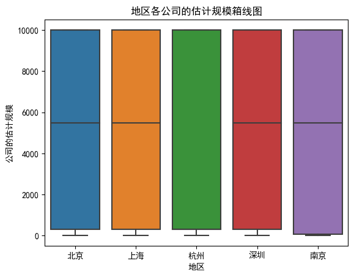

```python
sns.boxplot(data=x3,
    x="地区",y="公司的估计规模")
plt.title('地区各公司的估计规模箱线图')
plt.show()
```

### 公司领域分析

```python
job3['公司领域'].unique()
```

```
array(['通信/网络设备', '计算机软件', '电子商务', '移动互联网', '互联网', 'O2O', '人力资源服务',
       '其他行业', '物流/仓储', '在线教育', '银行', '企业服务', '汽车生产', '智能硬件', '贸易/进出口',
       '培训机构', '化工', '游戏', '医疗健康', '数据服务', '物业服务', '运营商/增值服务', '4S店/后市场',
       '非盈利机构', '基金', '广告/公关/会展', '房地产开发', '环保', '服装/纺织/皮革', '互联网金融',
       '社交网络', '文化/体育/娱乐', '专利/商标/知识产权', '计算机服务', '新零售', '食品/饮料/烟酒',
       '广告营销', '餐饮', '新能源', '其他专业服务', '船舶/航空/航天', '农/林/牧/渔', '机械设备/机电/重工',
       '检测/认证', '生活服务', '交通/运输', '学术/科研', '电子/半导体/集成电路', '信息安全', '批发/零售',
       '仪器仪表/工业自动化', '其他服务业', '建材', '租赁/拍卖/典当/担保', '咨询', '旅游', '投资/融资',
       '财务/审计/税务', '分类信息', '政府/公共事业', '医疗/护理/卫生', '媒体', '制药', '医疗设备/器械',
       '证券/期货', '院校', '计算机硬件', '工程施工', '珠宝/首饰', '石油/石化', '日化', '家具/家电/家居',
       '建筑设计', '电力/热力/燃气/水利', '原材料及加工/模具', '汽车零部件', '办公用品及设备', '广播/影视',
       '音乐/视频/阅读', '装修装饰', '地产经纪/中介', '婚庆/摄影'], dtype=object)
```

```python
job4=job3.copy()
```

```python
x4= job4['公司领域'].value_counts()
x4=x4.sort_values(ascending=False)#降序
x4
```

```
计算机软件    893
互联网      499
移动互联网    186
数据服务     154
电子商务     120
        ...
非盈利机构      1
制药         1
石油/石化      1
日化         1
婚庆/摄影      1
Name: 公司领域, Length: 82, dtype: int64
```

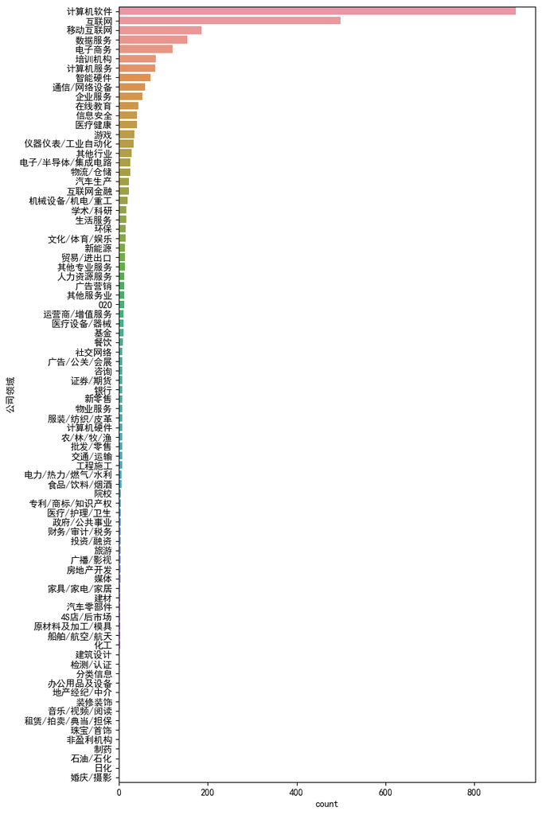

```python
plt.figure(figsize=(8,15))
sns.countplot(data=job4, y='公司领域',order=x4.index)
plt.show()
```

- 从公司领域上分析，发布招聘的行业具有多样性，招聘的行业领域主要集中在计算机软件和互联网相关数据的数据服务上面，

### 经验分析

```python
job4.head(2)
```

|  | 标题 | 地区 | 公司名 | 公司领域 | 薪资 | 经验 | 规模 | 福利 | 详情页 | 薪资标签 | 底薪 | 顶薪 | 公司的估计规模 | 底薪标签 |
| --- | --- | --- | --- | --- | --- | --- | --- | --- | --- | --- | --- | --- | --- | --- |
| 0 | 数据分析师 | 北京 | 锐捷网络 | 通信/网络设备 | 20-30K·13薪 | 3-5年本科 | 1000-9999人 | 通讯补贴，节日福利，五险一金，定期体检，带薪年假，餐补，包吃，加班补助，员工旅游，零食下午茶... | https://www.zhipin.com/job_detail/42975c4fd5ea... | 双薪日工资 | 666.666667 | 1000.000000 | 5499.5 | 日底薪在600以上 |
| 1 | 数据分析师 | 上海 | 中电金信 | 计算机软件 | 15-25K | 经验不限本科 | 10000人以上 | 定期体检，节日福利，五险一金，补充医疗保险，带薪年假，零食下午茶 | https://www.zhipin.com/job_detail/3f9754994eb4... | 月薪日工资 | 500.000000 | 833.333333 | 10000.0 | 日底薪在500-600 |

```python
# 中专/中技 统一为中专
job4['经验'] = job4['经验'].str.replace('中专/中技','中专').str.replace('及以下','')
# 存在周/天判断为兼职， 否则全职
job4['状态'] = job4['经验'].apply( lambda x: '兼职' if '周' in x else '全职'  )
# 取学历
job4['学历'] = job4['经验'].str[-2:]
# 取工作年限，兼职的工作年限取无
job4['工作年限'] =  job4['经验'].str[:-2].str.replace('学历','')
ind5=(job4['状态']=='兼职')
job4.loc[ind5,['工作年限']]='无'
```

- lambda 是一个匿名函数，用于对job4数据框中的'经验'列进行操作。具体来说，lambda 函数的作用是根据'经验'列的值来确定'状态'列的值。
- lambda x: '兼职' if '周' in x else '全职' 这个lambda函数的定义可以解释为：
- x 是输入的参数，表示'经验'列中的每个值。
- if '周' in x 是一个条件语句，检查字符串x中是否包含'周'。
- 如果条件成立，即'周'在x中，那么返回'兼职'。
- 如果条件不成立，即'周'不在x中，那么返回'全职'。

```python
job4.head(2)
```

|  | 标题 | 地区 | 公司名 | 公司领域 | 薪资 | 经验 | 规模 | 福利 | 详情页 | 薪资标签 | 底薪 | 顶薪 | 公司的估计规模 | 底薪标签 | 状态 | 学历 | 工作年限 |
| --- | --- | --- | --- | --- | --- | --- | --- | --- | --- | --- | --- | --- | --- | --- | --- | --- | --- |
| 0 | 数据分析师 | 北京 | 锐捷网络 | 通信/网络设备 | 20-30K·13薪 | 3-5年本科 | 1000-9999人 | 通讯补贴，节日福利，五险一金，定期体检，带薪年假，餐补，包吃，加班补助，员工旅游，零食下午茶... | https://www.zhipin.com/job_detail/42975c4fd5ea... | 双薪日工资 | 666.666667 | 1000.000000 | 5499.5 | 日底薪在600以上 | 全职 | 本科 | 3-5年 |
| 1 | 数据分析师 | 上海 | 中电金信 | 计算机软件 | 15-25K | 经验不限本科 | 10000人以上 | 定期体检，节日福利，五险一金，补充医疗保险，带薪年假，零食下午茶 | https://www.zhipin.com/job_detail/3f9754994eb4... | 月薪日工资 | 500.000000 | 833.333333 | 10000.0 | 日底薪在500-600 | 全职 | 本科 | 经验不限 |

```python
job4['学历'].unique()
```

```
array(['本科', '硕士', '不限', '大专', '高中', '中专', '博士', '初中'], dtype=object)
```

```python
experience = job4['学历'].value_counts()
experience
```

```
大专    1205
本科    1162
不限     258
硕士     193
中专      32
高中      31
博士      29
初中       3
Name: 学历, dtype: int64
```

```python
# 数据格式化
from pyecharts.charts import Bar,WordCloud,Map,Pie,PictorialBar
from pyecharts import options as opts
from pyecharts.globals import ThemeType
p_data = [list(z) for z in zip(experience.index, experience)] # 数据格式  [['大专', 1090],['本科', 970],]

# 绘制饼图
pie = (
    Pie(init_opts=opts.InitOpts(theme=ThemeType.WHITE)) # 实例化、初始化图表的主题为暗色主题

    .add('学历', p_data, radius=['40%', '70%'] ) # 添加绘图数据，系列名称为“学历”，数据源为p_data,radius设置了饼图的内外半径
    .set_series_opts( label_opts=opts.LabelOpts(formatter="{b}:{d}%") ) # 设置标签的显示格式，{b}表示扇区的名称，{d}表示扇区的百分比
    .set_global_opts(    #设置全局选项，
#         title_opts=opts.TitleOpts( # 标题设置
#             title="经验学历占比图",
#             pos_left='center',
#             pos_top='center'),

#         visualmap_opts=opts.VisualMapOpts( # 颜色设置
#             is_show=False,  # 不显示颜色的柱子
#             min_=experience.min(), # 颜色值范围大小
#             max_=experience.max(),
#             range_color=['#edf8fb','#b2e2e2','#66c2a4','#2ca25f','#006d2c']),

        legend_opts=opts.LegendOpts(is_show=False, pos_top='5%'), # 不显示标签，并将图例位置设置在图标上方5%的位置
    )

)
pie.render_notebook()
```

- 发布的招聘要求中，学历普遍要求大专及本科学历

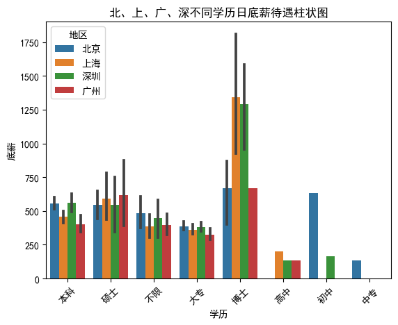

```python
#北京、上海和广州市不同学历要求下日底薪分析情况
ind6= (job4['地区']=='北京') | (job4['地区']=='上海') |(job4['地区']=='广州') |(job4['地区']=='深圳')
x5 = job4.loc[ind6,['学历', '底薪','地区']]
sns.barplot(data=x5, x='学历', y='底薪', hue='地区')
plt.xticks(rotation=45)
plt.title('北、上、广、深不同学历日底薪待遇柱状图')
plt.show()
```

```python
job4['工作年限'].unique()
```

```
array(['3-5年', '经验不限', '5-10年', '1-3年', '1年以内', '无', '在校/应届', '10年以上',
       '应届生'], dtype=object)
```

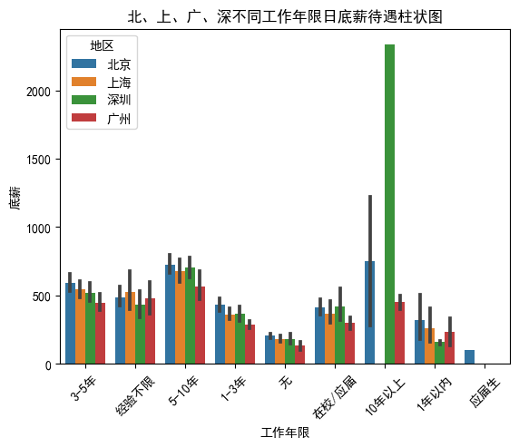

```python
#北京、上海和广州市不同工作年限要求下日底薪分析情况
ind6= (job4['地区']=='北京') | (job4['地区']=='上海') |(job4['地区']=='广州') |(job4['地区']=='深圳')
x6 = job4.loc[ind6,['工作年限', '底薪','地区']]
sns.barplot(data=x6, x='工作年限', y='底薪', hue='地区')
plt.xticks(rotation=45)
plt.title('北、上、广、深不同工作年限日底薪待遇柱状图')
plt.show()
```

### 福利待遇分析（词云图）

```python
import pyecharts.options as opts
from pyecharts.charts import WordCloud
```

```python
job4.head(2)
```

|  | 标题 | 地区 | 公司名 | 公司领域 | 薪资 | 经验 | 规模 | 福利 | 详情页 | 薪资标签 | 底薪 | 顶薪 | 公司的估计规模 | 底薪标签 | 状态 | 学历 | 工作年限 |
| --- | --- | --- | --- | --- | --- | --- | --- | --- | --- | --- | --- | --- | --- | --- | --- | --- | --- |
| 0 | 数据分析师 | 北京 | 锐捷网络 | 通信/网络设备 | 20-30K·13薪 | 3-5年本科 | 1000-9999人 | 通讯补贴，节日福利，五险一金，定期体检，带薪年假，餐补，包吃，加班补助，员工旅游，零食下午茶... | https://www.zhipin.com/job_detail/42975c4fd5ea... | 双薪日工资 | 666.666667 | 1000.000000 | 5499.5 | 日底薪在600以上 | 全职 | 本科 | 3-5年 |
| 1 | 数据分析师 | 上海 | 中电金信 | 计算机软件 | 15-25K | 经验不限本科 | 10000人以上 | 定期体检，节日福利，五险一金，补充医疗保险，带薪年假，零食下午茶 | https://www.zhipin.com/job_detail/3f9754994eb4... | 月薪日工资 | 500.000000 | 833.333333 | 10000.0 | 日底薪在500-600 | 全职 | 本科 | 经验不限 |

```python
words = job4['福利'].str.split('，').explode().value_counts()#.explode()将列表中的元素展开为多行，生成一个新的Series对象
words
```

```
五险一金      2353
带薪年假      2146
节日福利      2087
年终奖       1995
定期体检      1772
          ...
生日关怀         1
亲情1+1        1
中秋月饼福利       1
上海周边游        1
丰富的团建活       1
Name: 福利, Length: 390, dtype: int64
```

```python
# 数据构造
p_data = [list(z) for z in zip(words.index, words)] # 数据格式  [['五险', 1090],['年终奖', 970],]

welfare=(
    WordCloud()
    .add(series_name="福利待遇分析", data_pair=p_data, word_size_range=[6, 66])
    .set_global_opts(
        title_opts=opts.TitleOpts(
            title="福利待遇分析", title_textstyle_opts=opts.TextStyleOpts(font_size=23)
        ),
        tooltip_opts=opts.TooltipOpts(is_show=True),
    )

)
welfare.render_notebook()
```

- 主要的福利待遇有：五险一金、带薪年假、节日福利、年终奖、定期体检等。